# Notes_L5

Paolo Crosetto

10/15/2021

## GGplot avancé

### recap ggplot

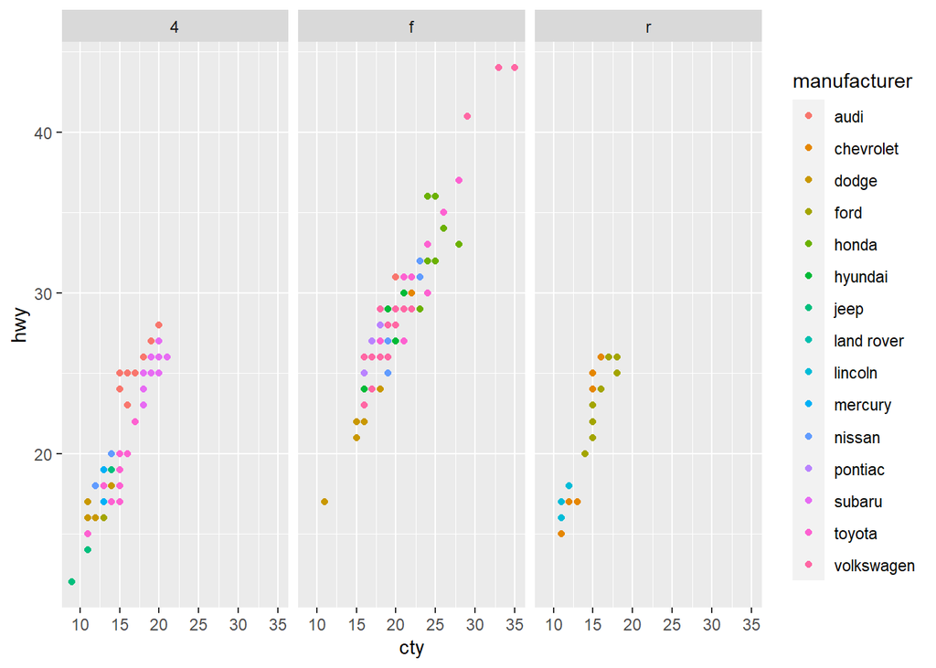

```r
mpg %>%
  ggplot()+
  aes(x= cty, y = hwy, color = manufacturer)+
  geom_point()+
  facet_wrap(~drv)
```

plot de base pour travailler

```r
base <- iris %>%
  ggplot() +
  aes(x = Sepal.Length, y = Sepal.Width,
      color = Species, size = Petal.Width)+
  geom_point()
```

## coord_*

#### coord_flip()

ça inverse les axes:

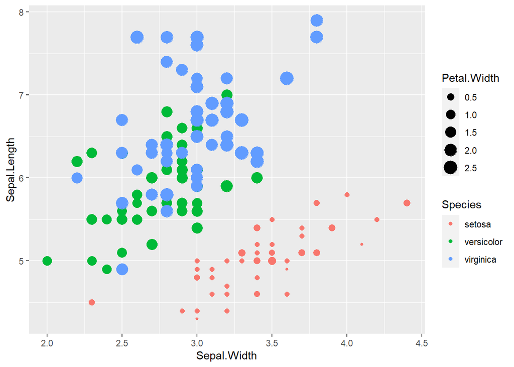

```r
base + coord_flip()
```

### coord_cartesian() changer les limites ou autres propriétés des coordonnées

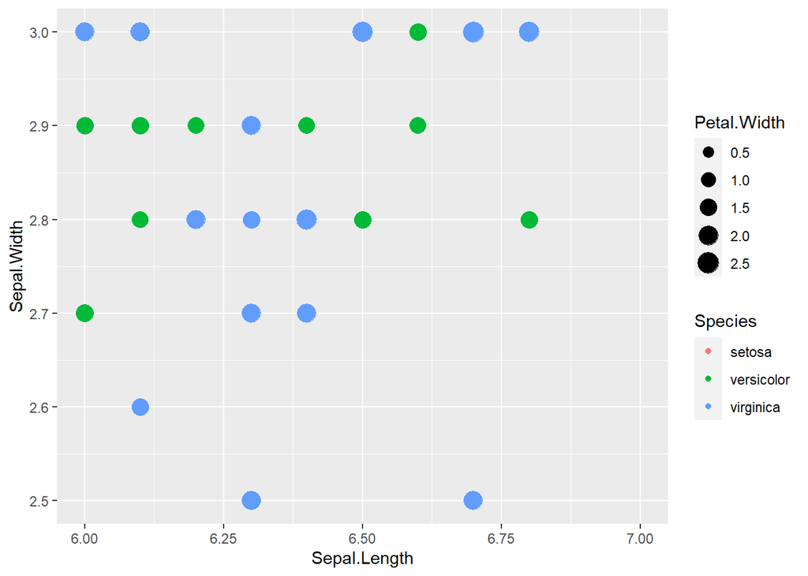

```r
base + coord_cartesian(xlim = c(6,7), ylim = c(2.5,3))
```

### coord_fixed() and coord_equal()

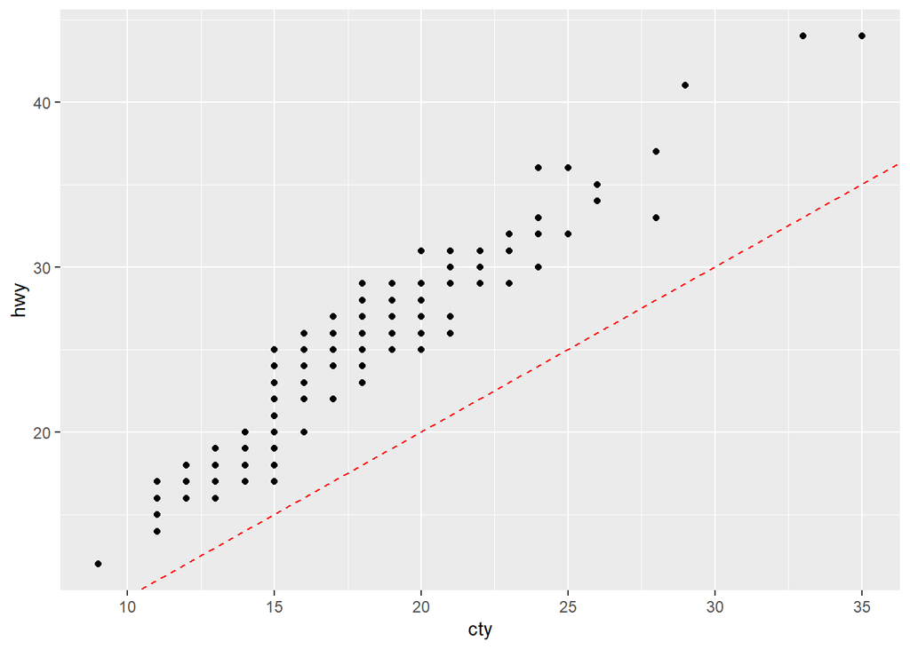

```r
base_mpg <- mpg %>%
  ggplot() +
  aes(cty, hwy) +
  geom_point() +
  geom_abline(slope = 1, intercept = 0, color="red", linetype = "dashed")

base_mpg
```

créer des coordonnées égales: on obtient le controle sur le ratio des unitées de l’axe X et de l’axe Y

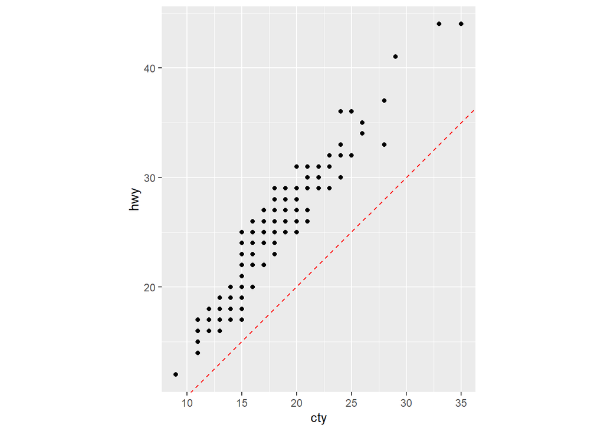

```r
base_mpg + coord_equal()
```

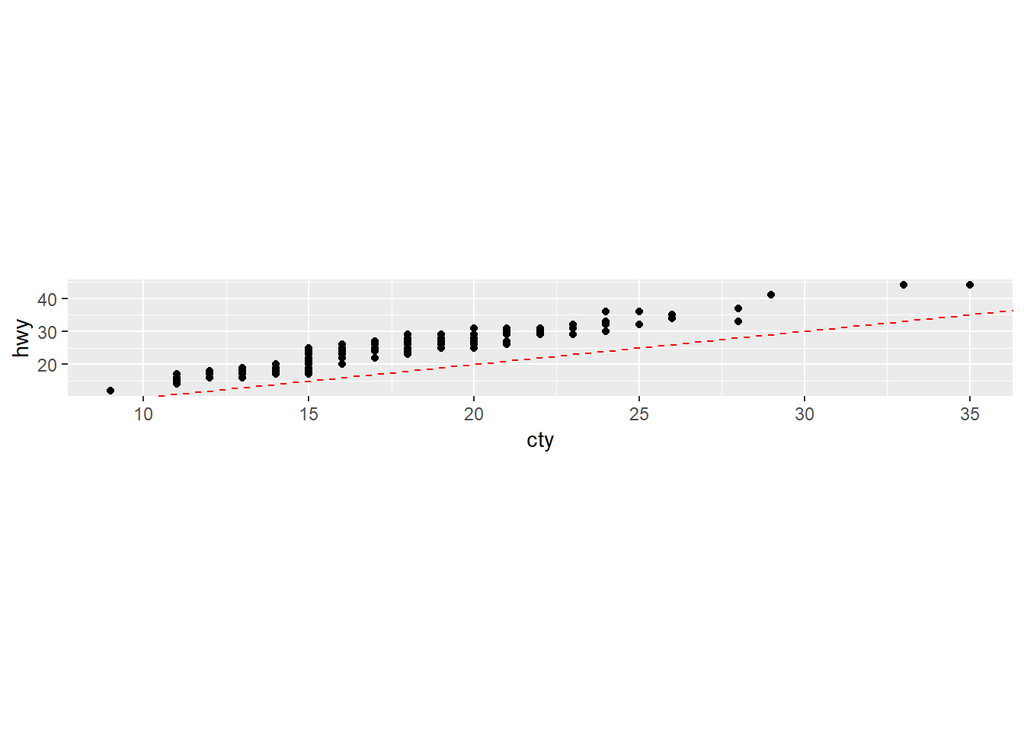

```r
base_mpg + coord_equal(ratio = 1/10)
```

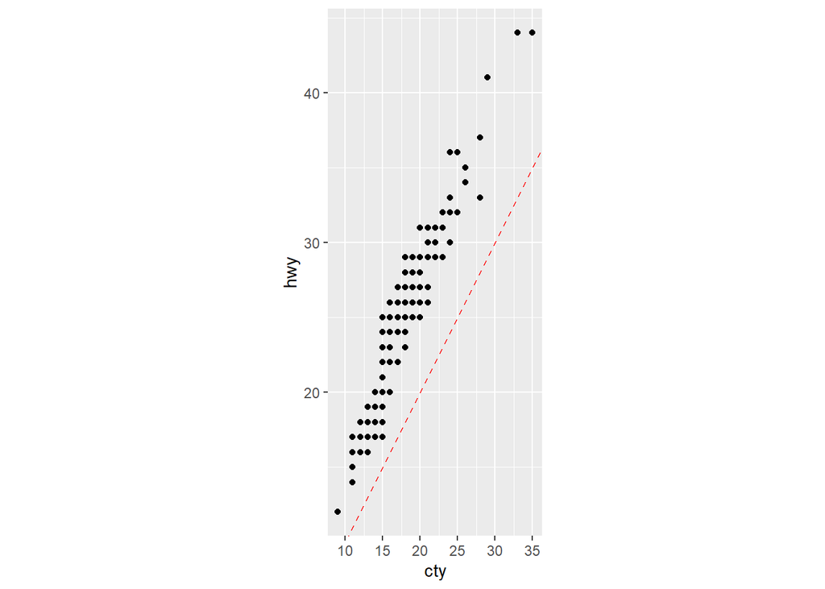

```r
base_mpg + coord_equal(ratio = 2)
```

## coord_fixed

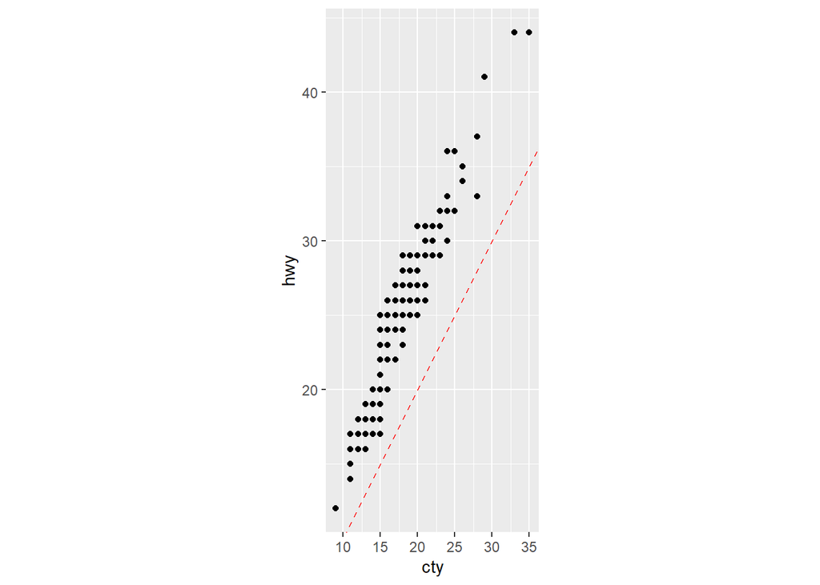

```r
base_mpg + coord_fixed(ratio = 2)
```

### coordonnées polaires:

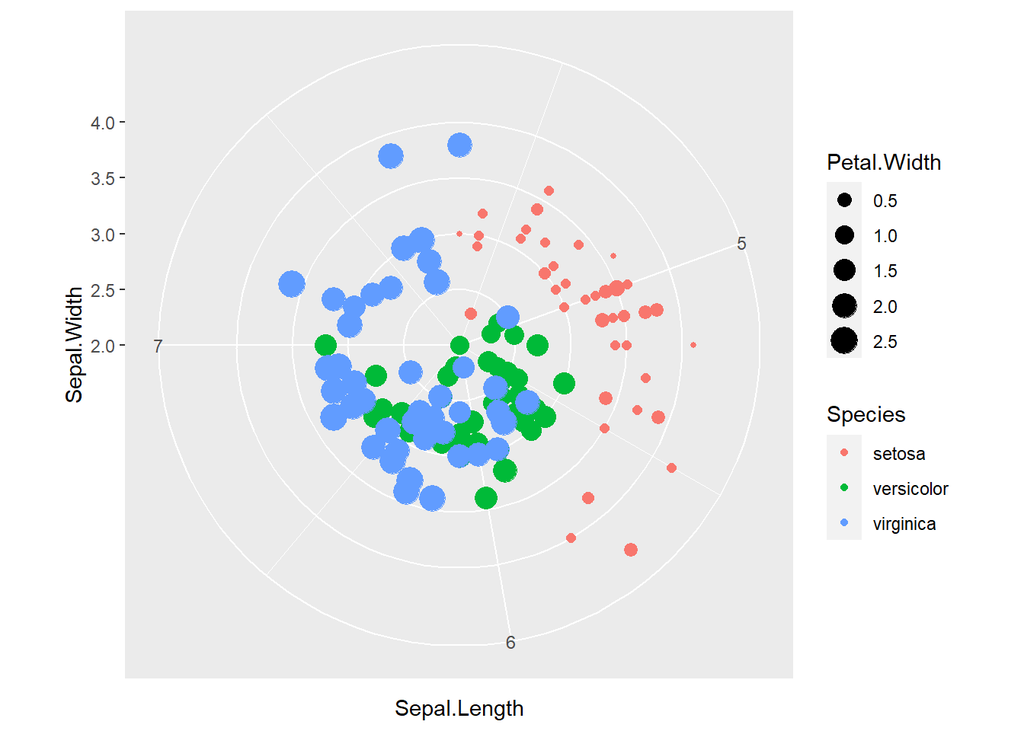

```r
base + coord_polar()
```

### camemberts : pie charts

- un pie chart c’est juste une barre en coordonées polaires! on commence par un graphique en barre

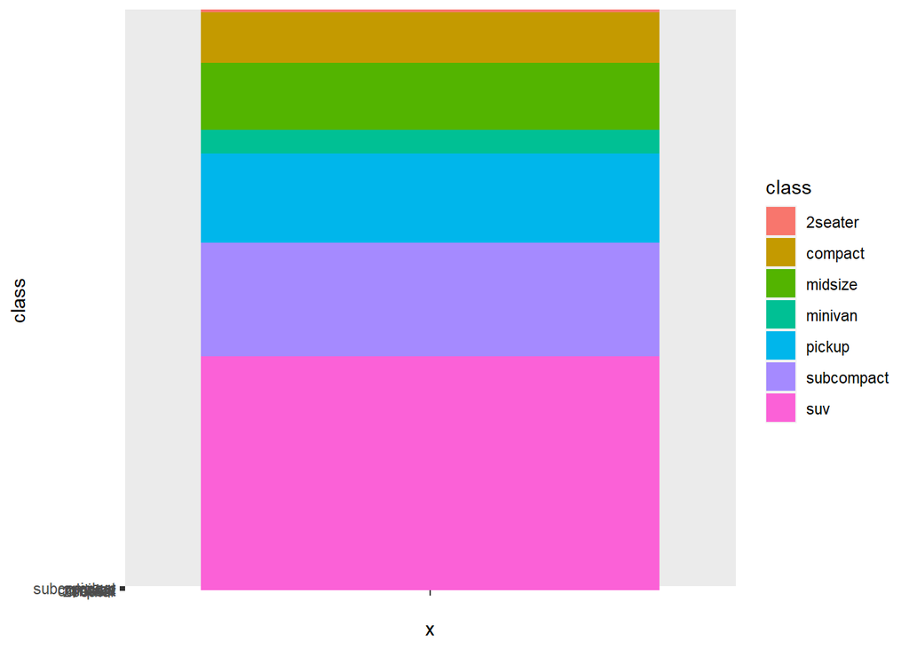

```r
barre <- mpg %>%
  ggplot() +
  aes(x="", y = class, fill=class)+
  geom_col()
barre
```

on le transfome en pie chart:

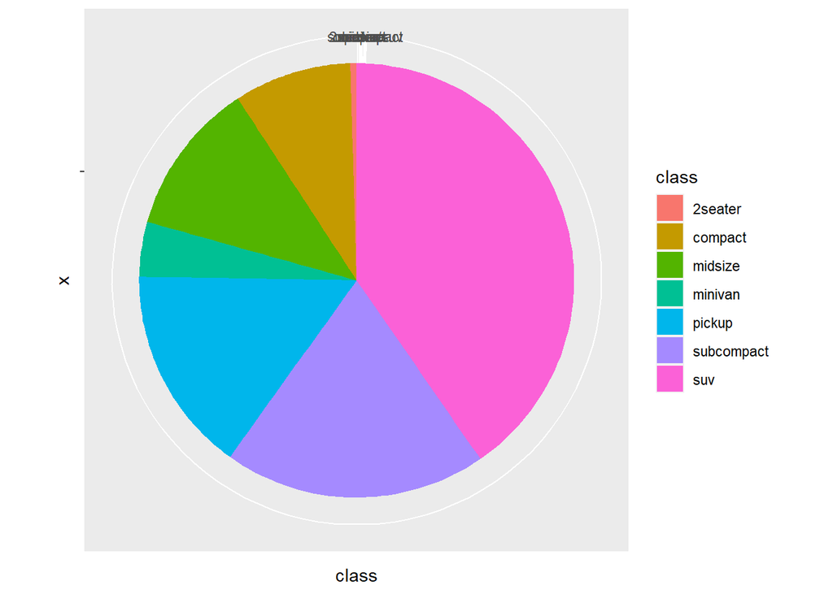

```r
barre + coord_polar(theta = "y")
```

### exemple avec babynames:

```r
library(babynames)
```

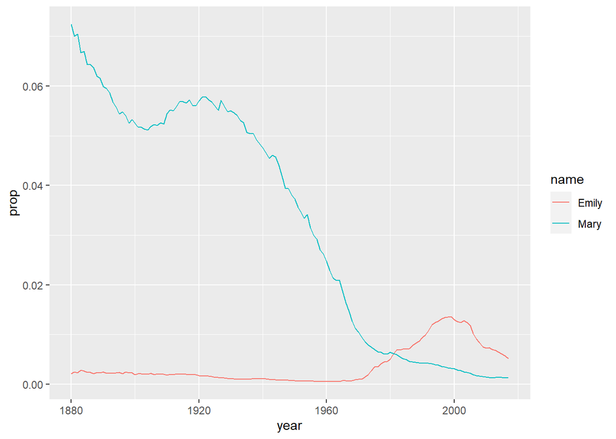

```r
linear <- babynames %>%
  filter(name %in% c("Mary","Emily") & sex == "F") %>%
  ggplot() +
  aes(x=year, y=prop, color=name) +
  geom_line()
linear
```

version polaire:

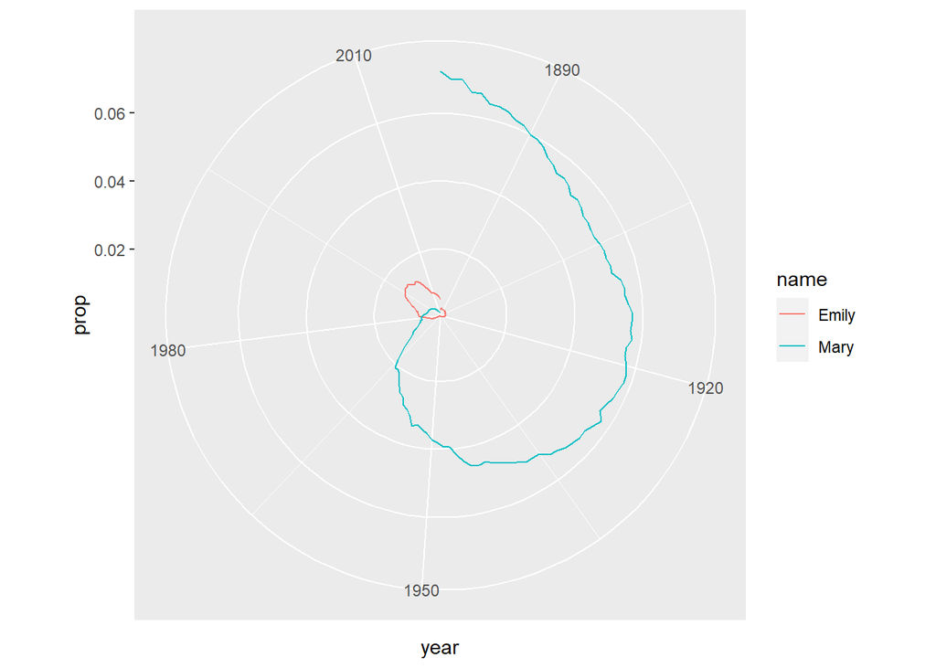

```r
linear + coord_polar()
```

### chart en radar avec coord_polar

créer des données sur deux villes françaises pour les comparer:

```r
df <- tibble(ville = c("Grenoble", "Paris") ,
               taille = c(2,5) ,
               distance_mer = c(3,2) ,
               distance_montagne = c(0,5) ,
               sympa = c(5,0) ,
               riche = c(3,4))
df
```

```
## # A tibble: 2 x 6
##   ville    taille distance_mer distance_montagne sympa riche
##   <chr>     <dbl>        <dbl>             <dbl> <dbl> <dbl>
## 1 Grenoble      2            3                 0     5     3
## 2 Paris         5            2                 5     0     4
```

1. tidy the data fram -> une variable par colonne et une observation par ligne:

```r
df_tidy <- df %>%
  pivot_longer(-ville, names_to = "caracteristique", values_to = "note")
df_tidy
```

```
## # A tibble: 10 x 3
##    ville    caracteristique    note
##    <chr>    <chr>             <dbl>
##  1 Grenoble taille                2
##  2 Grenoble distance_mer          3
##  3 Grenoble distance_montagne     0
##  4 Grenoble sympa                 5
##  5 Grenoble riche                 3
##  6 Paris    taille                5
##  7 Paris    distance_mer          2
##  8 Paris    distance_montagne     5
##  9 Paris    sympa                 0
## 10 Paris    riche                 4
```

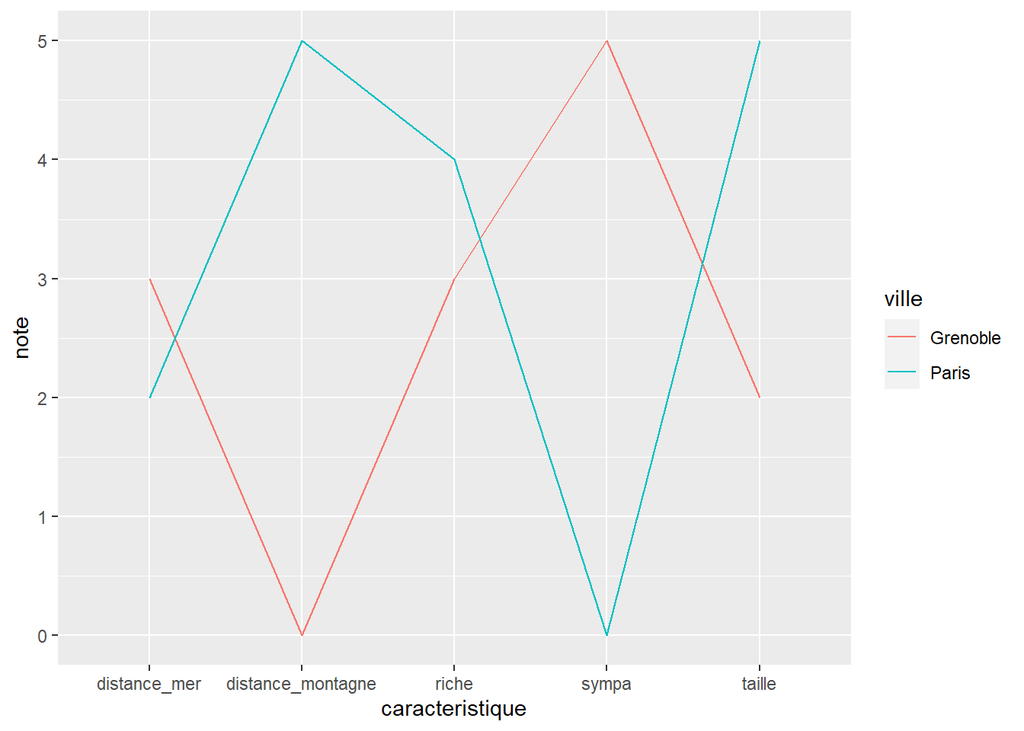

```r
linear <- df_tidy %>%
  ggplot()+
  aes(x = caracteristique, y=note, color=ville, group=ville)+
  geom_line()
linear
```

3. on fait un radar avec coord_polar()

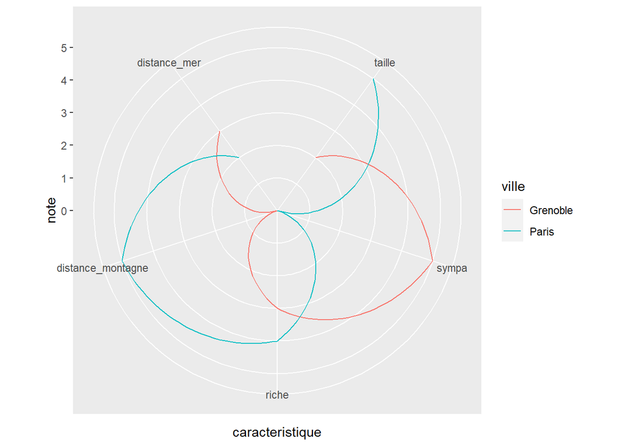

```r
polar <- linear + coord_polar(direction = -1, clip = "off")
polar
```

-scale agit sur les geom_*

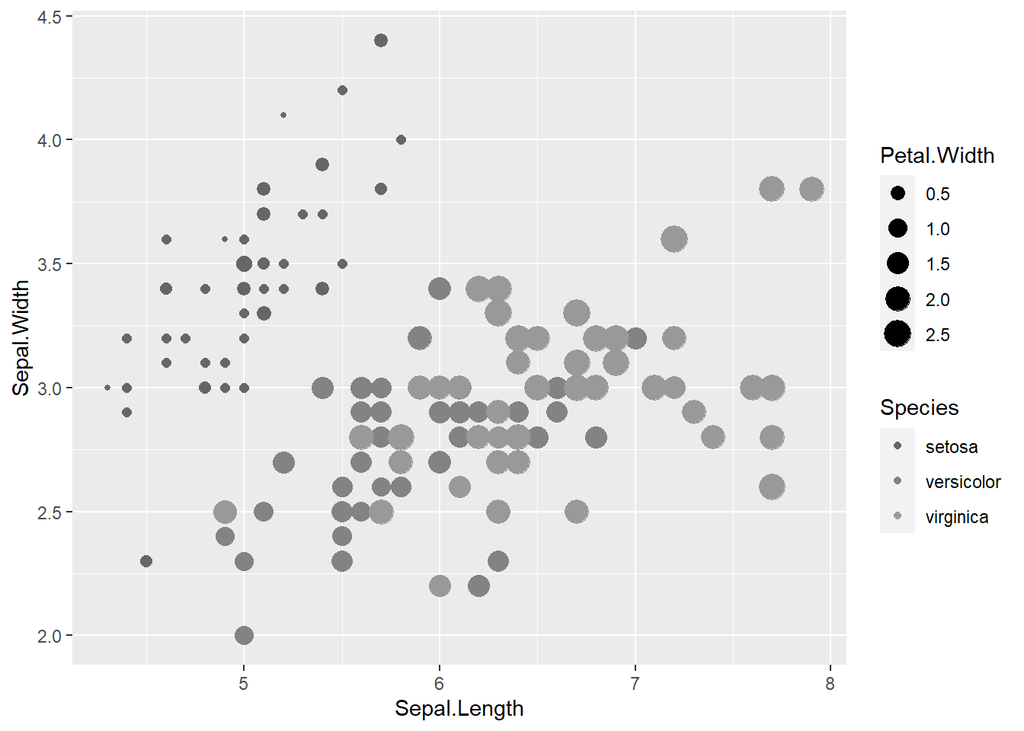

```r
base + scale_color_grey(start = 0.4, end=0.6)
```

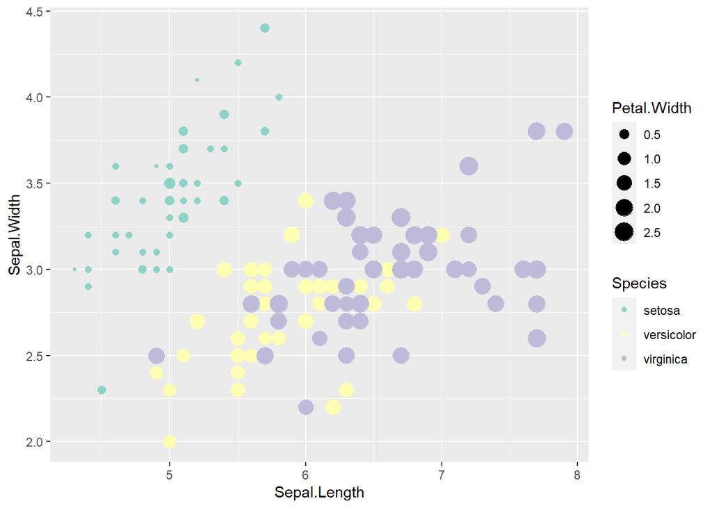

```r
base + scale_color_brewer(palette = "Set3")
```

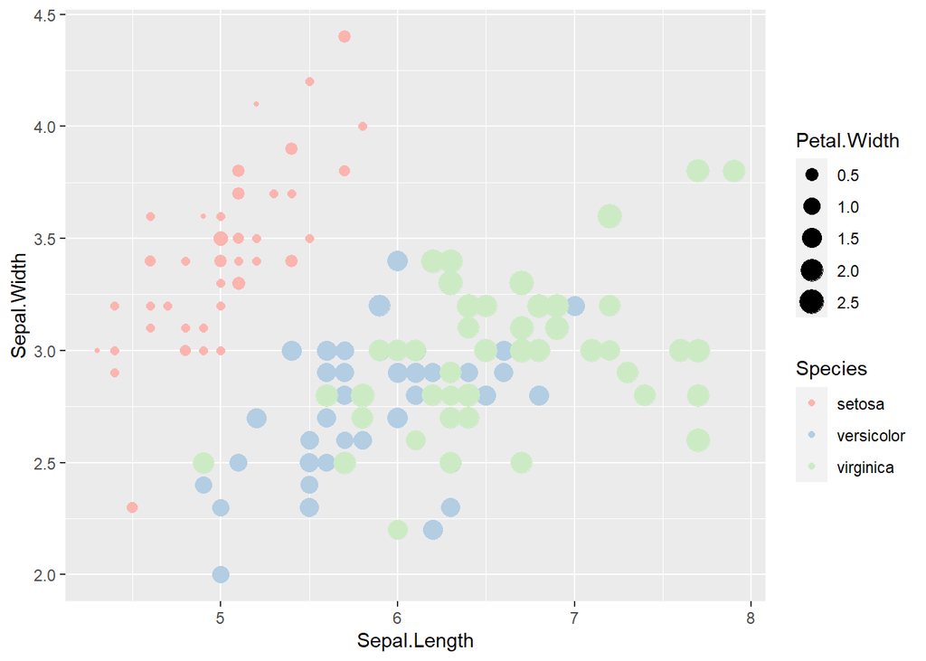

```r
base + scale_color_brewer(palette = "Pastel1")
```

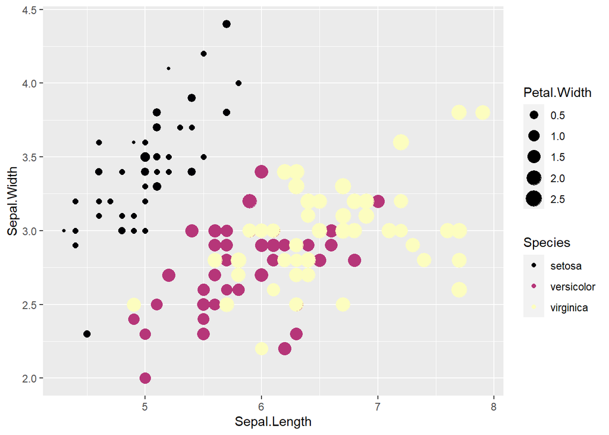

```r
base + scale_color_viridis_d(option = "magma")
```

on peut directement faire les couleurs à la main:

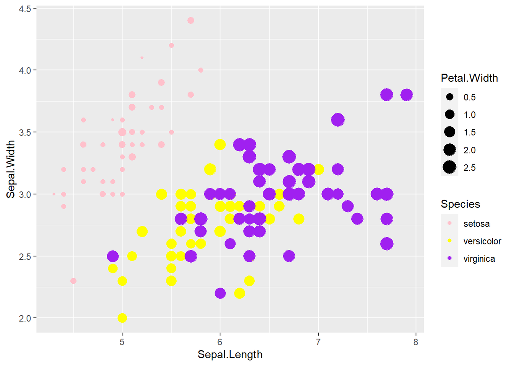

```r
base + scale_color_manual(values = c("pink", "yellow", "purple"))
```

### échelle continue

exemple avec couleurs continues:

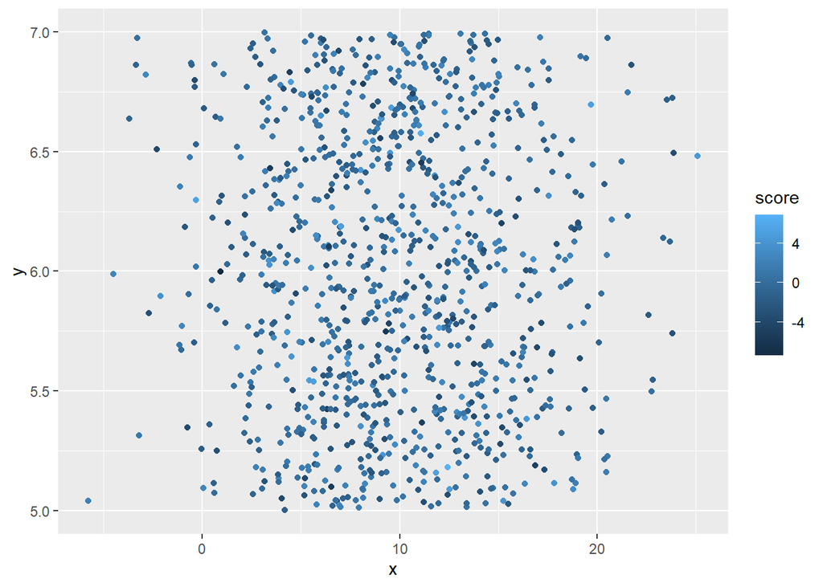

```r
df <- tibble(x = rnorm(1000, mean=10, sd=5),
             y = runif(1000, min=5, max=7),
             score = rnorm(1000, mean=0, sd=2))

base_rnorm <- df %>%
  ggplot()+
  aes(x=x, y=y, color = score)+
  geom_point()
base_rnorm
```

on n’y voit rien du tout avec les oculeurs par défaut! changer le gradient

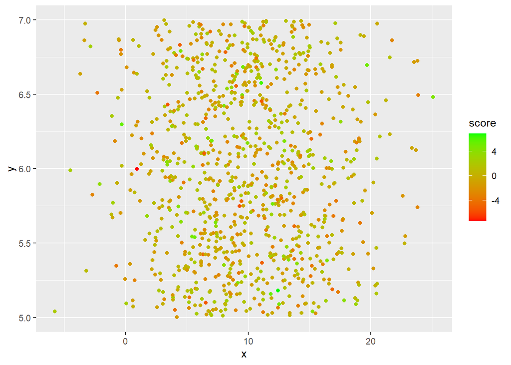

```r
base_rnorm + scale_color_gradient(low="red", high = "green")
```

gradient avec 3 points:

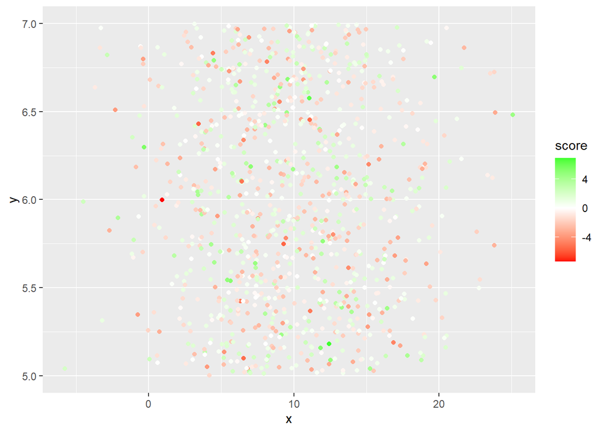

```r
base_rnorm + scale_color_gradient2(low="red", mid="white", high = "green")
```

gradient avec N passages:

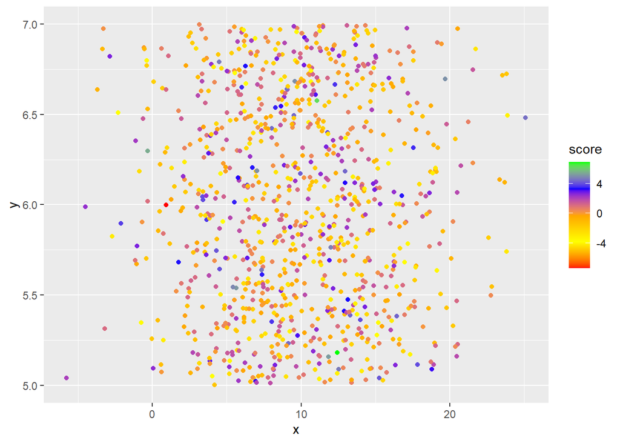

```r
base_rnorm + scale_color_gradientn(colors = c("red", "yellow", "orange", "blue","green"))
```

## entre continue et discret, on a des “binned”:

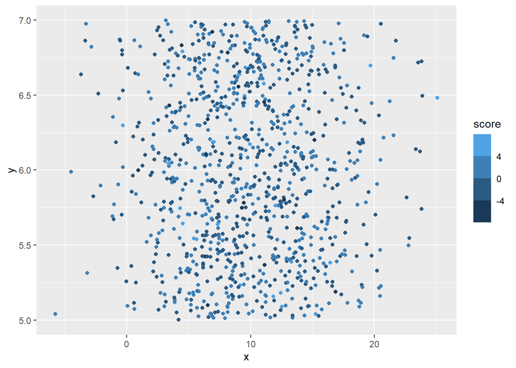

```r
base_rnorm + scale_color_binned()
```

# OTHER THINGS TO CHANGE

### size

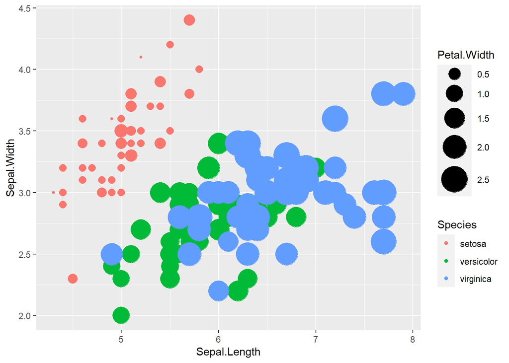

```r
base + scale_size_continuous(range = c(1,12))
```

### fill vs color

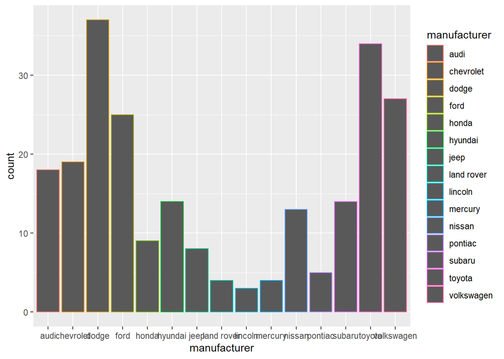

```r
mpg %>%
  ggplot()+
  aes(x = manufacturer, color = manufacturer) +
  geom_bar()
```

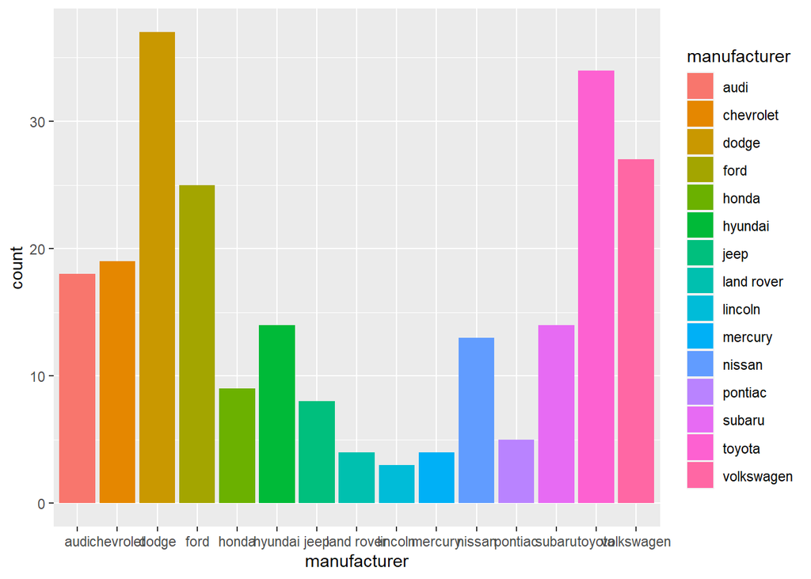

```r
barre2 <- mpg %>%
  ggplot()+
  aes(x = manufacturer, fill = manufacturer) +
  geom_bar()
barre2
```

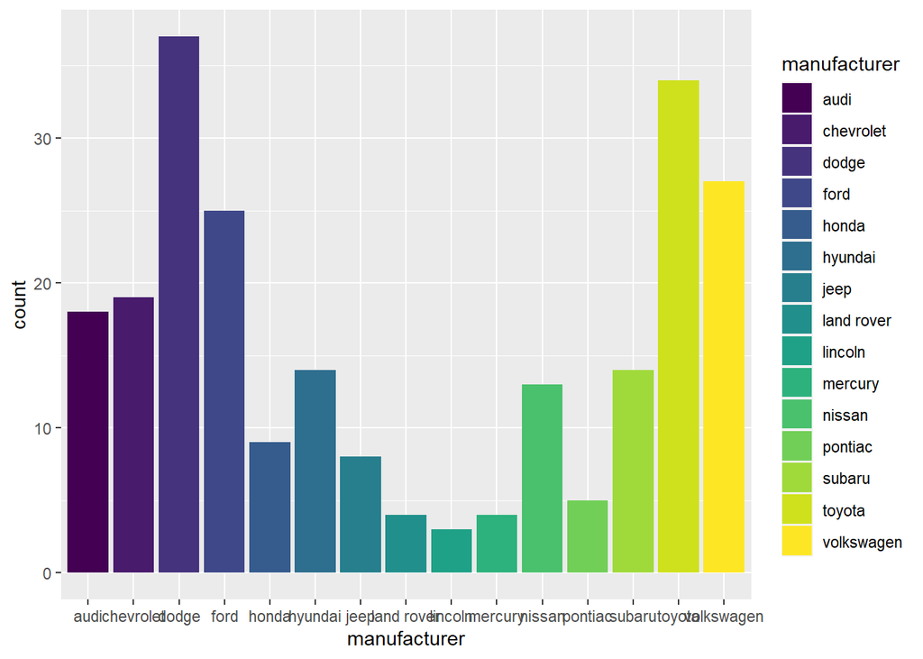

```r
mpg %>%
  ggplot()+
  aes(x = manufacturer, fill = manufacturer) +
  geom_bar() +
  scale_fill_viridis_d()
```